# Cheatsheet

Julia Romanowska

2022-05-10

This is based on the work presented in Khalife, J. T. **(2006)**. *Threshold for the introduction of programming: Providing learners with a* *simple computer model.* Proceedings of the International Conference on Information Technology Interfaces, ITI, 71–76. https://doi.org/10.1109/iti.2006.1708454

## Generic instructions

We can use pseudocode to write down instructions before putting everything into a runnable code.

### Declaration

Each variable has a type, e.g.,

- `numeric` (any number, integer or float),
- `string` (one or more characters, surrounded by "),
- `date` (date and/or time),
- `boolean` (`TRUE` or `FALSE`).

If we declare a variable without assigning a value to it, it has always the default value: `NA` = *no value*.

In pseudo-code, it’s good to declare a variable *before* we assign anything to it.

```
Numeric a
```

This reserves an empty space in RAM that is enough to hold any single numeric value and then, stores the address of this RAM space under name `a`.

> NOTE: when writing R code, we do not need to *declare* a variable before assigning a value, system will do it invisibly for us when executing the code. However, when learning how to translate a problem from natural language to a code, it’s a good idea to show each declaration explicitly.

> NOTE (2): **Be careful when naming variables!** In each programming language, there are special names that should not be used as variable names, e.g., `pi`, `break`. Short, abbreviated names are discouraged (e.g., `dnt2`, `tmp_a`), since these are not telling what type of values they would store. Try names such as `blood_pressure` or `AllPatientsHospital` instead.

### Input

From a file or keyboard (standard input).

```
KeyboardRead name
```

This waits for the user to enter a sequence of signs and press `Enter` on a keyboard. Then, the sequence of signs will be stored in the variable `name`.

> NOTE: the *type* of the variable needs to be defined beforehand.

### Output

To the screen (standard output) or to a file.

```
ScreenWrite "Today is ", day_of_week
```

### Assignment

To store values in memory, e.g., when performing some operations on values, we need to assign these to variables.

```
circumf <- 2*pi*radius
```

> NOTE: *Before* this line of pseudocode, there should be declaration of `circumf` and `radius` numeric variables. `pi` is usually pre-defined in various programming languages.

## Diagram of instructions flow

When translating a problem from natual language to pseudo-code, it’s useful to create a diagram that shows small steps that are needed for the computer to perform a task.

Here are building blocks:

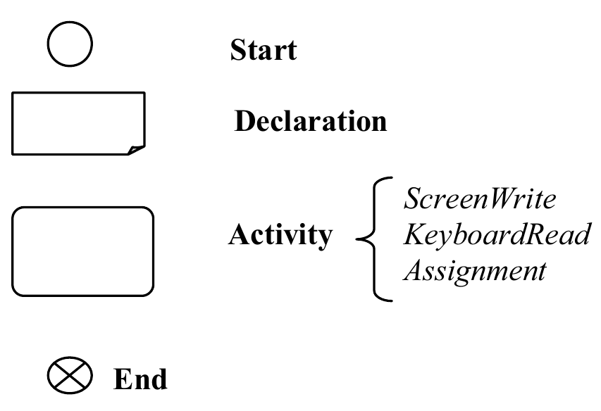